# wk2 milestone report

JeremiShane

September 17, 2018

# Executive Summary

The following report demonstrates familiarity and facility with the three English language text data files for the Swiftkey capstone project for Johns Hopkins Data Scinece certification on Coursera. The purpose of the project is to publish a shiny app that will predict the next word as users type in text.

```
    The three files are:
    1. blogs
    2. twitter
    3. news
```

The following milestone report shows basic exploration of the files and the terms. Next steps are to further scrub the terms, evaluate other data sources to add to the corpus, and build a Naive Bayes predictive model that will predict the next word to be typed based on the last one, two or three words typed.

# Summary of the Files

```
##    Source FileSize_MB   Lines    Words Characters Words_Per_Line
## 1   blogs         200  899288 37546246  170389662       41.75108
## 2 twitter         159 2360148 30093369  134082634       12.75063
## 3    news         196 1010242 34762395  169860871       34.40997
##   Char_Per_Line Char_Per_Word
## 1         189.5          4.54
## 2          56.8          4.46
## 3         168.1          4.89
```

# Exploratory Analysis of the Files

## frequencies of words and word pairs

During this exploratory and model building phase, only a sample (100000 lines from each) of the files will be used for computational efficiency.  
More data will be included for the final training set.

After reading in the files, I first remove all non-ascii characters. After converting the files to a corpus, I use the tm package to cleanse the data then remove all infrequent terms which I have defined as occuring less than 13 times.

Using 13 as the threshold I determined that ~15% of the total terms will remain in the dataset. This is a dramatic reduction in the size of the corpus, and with the most relavent, predictive and predictable terms remaining.

Next Steps: 1. to stem or not to stem final training data 2. decide on additional data to include 3. build Naive Bayes predictive model 4. build application for predicting next word and post to web

Word cloud, Frequency of onegrams, and twograms below.

### Word Cloud

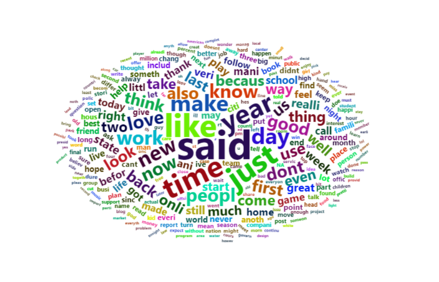

wordcloud

### Frequencies

#### Top 10 terms, and histogram of log frequencies of all terms

```
##    ngrams  freq        prop
## 1   said  29330 0.006769612
## 2   like  23225 0.005360526
## 3   just  22295 0.005145874
## 4   time  21864 0.005046396
## 5   year  19919 0.004597474
## 6   make  16895 0.003899509
## 7    day  16600 0.003831420
## 8    new  15533 0.003585148
## 9   work  14400 0.003323642
## 10  know  13929 0.003214931
```

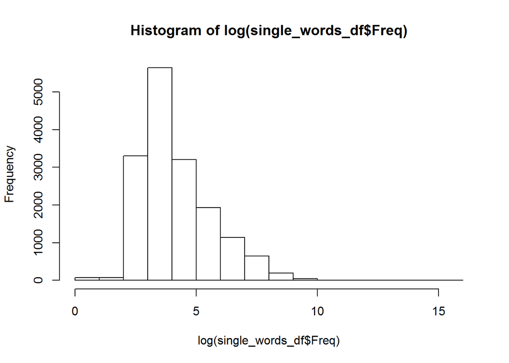

#### Top 10 bigrams

```r
twoFreq
```

```
##          ngrams freq         prop
## 1    last year  2231 0.0005149338
## 2     new york  1805 0.0004166093
## 3    right now  1576 0.0003637542
## 4     year ago  1515 0.0003496749
## 5    dont know  1512 0.0003489825
## 6    look like  1495 0.0003450587
## 7    last week  1322 0.0003051288
## 8  high school  1313 0.0003030516
## 9    feel like  1274 0.0002940500
## 10   make sure  1054 0.0002432722
```

#### Top 10 trigrams

```r
threeFreq
```

```
##                  ngrams freq         prop
## 1        new york citi   234 5.400920e-05
## 2  presid barack obama   178 4.108392e-05
## 3          let us know   165 3.808341e-05
## 4         two year ago   161 3.716018e-05
## 5     happi mother day   149 3.439047e-05
## 6        new york time   124 2.862026e-05
## 7    gov chris christi   111 2.561975e-05
## 8       happi new year   107 2.469652e-05
## 9       st loui counti   101 2.331166e-05
## 10     first time sinc    94 2.169600e-05
```

# Appendix

## R Files

skbt_22.R 1. read in data from files 2. build word list that contain the dictionary of words (with repeats) 3. clean out profanity and junk 4. ngrams 5. group on unique words and sort by frequency

## Assignment

The goal of this project is just to display that you’ve gotten used to working with the data and that you are on track to create your prediction algorithm. Please submit a report on R Pubs (http://rpubs.com/) that explains your exploratory analysis and your goals for the eventual app and algorithm. This document should be concise and explain only the major features of the data you have identified and briefly summarize your plans for creating the prediction algorithm and Shiny app in a way that would be understandable to a non-data scientist manager. You should make use of tables and plots to illustrate important summaries of the data set. The motivation for this project is to: 1. Demonstrate that you’ve downloaded the data and have successfully loaded it in.2. Create a basic report of summary statistics about the data sets.3. Report any interesting findings that you amassed so far.4. Get feedback on your plans for creating a prediction algorithm and Shiny app.

Review criteria 1. Does the link lead to an HTML page describing the exploratory analysis of the training data set? 2. Has the data scientist done basic summaries of the three files? Word counts, line counts and basic data tables? 3. Has the data scientist made basic plots, such as histograms to illustrate features of the data? 4. Was the report written in a brief, concise style, in a way that a non-data scientist manager could appreciate?

Tasks to accomplish

Exploratory analysis - perform a thorough exploratory analysis of the data, understanding the distribution of words and relationship between the words in the corpora. Understand frequencies of words and word pairs - build figures and tables to understand variation in the frequencies of words and word pairs in the data. Questions to consider

Some words are more frequent than others - what are the distributions of word frequencies? What are the frequencies of 2-grams and 3-grams in the dataset? How many unique words do you need in a frequency sorted dictionary to cover 50% of all word instances in the language? 90%? How do you evaluate how many of the words come from foreign languages? Can you think of a way to increase the coverage – identifying words that may not be in the corpora or using a smaller number of words in the dictionary to cover the same number of phrases?

The goal of this project is just to display that you’ve gotten used to working with the data and that you are on track to create your prediction algorithm. Please submit a report on R Pubs (http://rpubs.com/) that explains your exploratory analysis and your goals for the eventual app and algorithm. This document should be concise and explain only the major features of the data you have identified and briefly summarize your plans for creating the prediction algorithm and Shiny app in a way that would be understandable to a non-data scientist manager. You should make use of tables and plots to illustrate important summaries of the data set. The motivation for this project is to:

1. Demonstrate that you’ve downloaded the data and have successfully loaded it in.
2. Create a basic report of summary statistics about the data sets.
3. Report any interesting findings that you amassed so far.
4. Get feedback on your plans for creating a prediction algorithm and Shiny app.

Review criteria Does the link lead to an HTML page describing the exploratory analysis of the training data set? Has the data scientist done basic summaries of the three files? Word counts, line counts and basic data tables? Has the data scientist made basic plots, such as histograms to illustrate features of the data? Was the report written in a brief, concise style, in a way that a non-data scientist manager could appreciate?